# Joining Data Sets with Merge()

#### Inner join with merge()

The solution:

- An inner join between the two data frames by the common variable: customer id

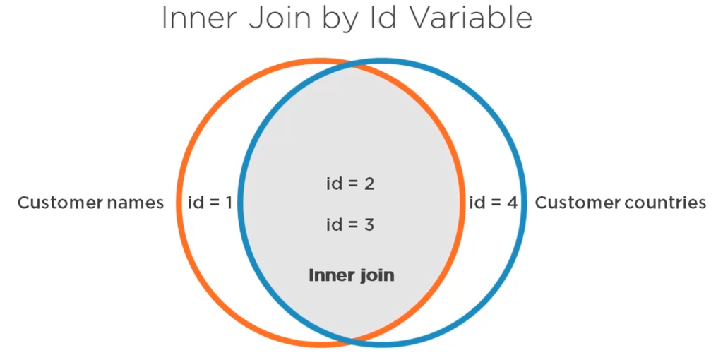

An Inner Join Illustration Image

```r
# Note: ?merge for documentation

merge(customer.names, customer.countries)
```

```
##   id    name customer_id country
## 1  1  Helena           2     USA
## 2  2  Astrid           2     USA
## 3  3 Eduardo           2     USA
## 4  1  Helena           3   Spain
## 5  2  Astrid           3   Spain
## 6  3 Eduardo           3   Spain
## 7  1  Helena           4     USA
## 8  2  Astrid           4     USA
## 9  3 Eduardo           4     USA
```

Note that merging them directly returns all possible combinations of rows between the two data frames:

- Three rows in each data frame - thus 3x3 = 9 rows, however…
- Most rows are invalid combinations
- To do a valid inner join, we need to explicitly state which common columns are meant to be involved

```r
merge(customer.names, customer.countries, by.x = 'id', by.y = 'customer_id')
```

```
##   id    name country
## 1  2  Astrid     USA
## 2  3 Eduardo   Spain
```

Thus, merging these two columns gives us the inner-join of the two data frames.

#### Good Habits

- Use unique ids
  - But what if rows are uniquely identified by two columns instead of one… a composite unique id??
  - Good news, you can use a composite unique id:

```r
names <- data.frame(first.name = c('Helena', 'Helena', 'Tom'), last.name = c('Jones', 'Troy', 'Jones'), age = c(20, 30, 40))
countries <- data.frame(first.name = c('Helena', 'Helena', 'Tom'), last.name = c('Jones', 'Troy', 'Jones'), country = c('USA', 'UK', 'USA'))

# Incorrect Merge
merge(names, countries, by.x = 'first.name', by.y = 'first.name')
```

```
##   first.name last.name.x age last.name.y country
## 1     Helena       Jones  20       Jones     USA
## 2     Helena       Jones  20        Troy      UK
## 3     Helena        Troy  30       Jones     USA
## 4     Helena        Troy  30        Troy      UK
## 5        Tom       Jones  40       Jones     USA
```

```r
# Correct Merge
merge(names, countries, by.x = c('first.name', 'last.name'), by.y = c('first.name', 'last.name'))
```

```
##   first.name last.name age country
## 1     Helena     Jones  20     USA
## 2     Helena      Troy  30      UK
## 3        Tom     Jones  40     USA
```

A Final point on good habits for inner joins:

- Natural Joins can be useful, but their use should be limited to avoid errors:
  - A Natural Join entails relying on column names for joining…
  - It is the default used by the merge() function call
  - An example of a natural join based on the two data frames previously used:

```r
merge(names, countries)
```

```
##   first.name last.name age country
## 1     Helena     Jones  20     USA
## 2     Helena      Troy  30      UK
## 3        Tom     Jones  40     USA
```

What’s happening here / why don’t we need to be explicit??

- By default, merge uses the intersection of column names (reference documentation: ?merge).
  - Since both data frames have a first.name and last.name column, we do not need to be explicit.
- This works out in this scenario, but with larger data frames it can become messy and should be used sparingly.

A middle-ground:

- Merge and use the by parameter, specifying the columns:

```r
merge(names, countries, by = c('first.name', 'last.name'))
```

```
##   first.name last.name age country
## 1     Helena     Jones  20     USA
## 2     Helena      Troy  30      UK
## 3        Tom     Jones  40     USA
```

Note, this works because we are explicitly choosing columns present in both data frames.

Recap:

- Inner joins are a great way to pull data with a common unique identifier
- What about pulling data with identifiers that are not common? Can this also be accomplished?
  - This is answered in the Left, Right, and Full Outer Joins Section.

### Left, Right, and Full Outer Joins

Here we gain more control over the joining results by understanding how to retrieve not only rows with common ids, but also other rows from your data frames.

#### Left Outer Joins

```r
# Setting the stage
customer.names <- data.frame(id = 1:3, name = c('Helena', 'Astrid', 'Eduardo'))
customer.countries <- data.frame(customer_id = 2:4, country = c('USA', 'Spain', 'USA'))

merge(customer.names, customer.countries, by.x = 'id', by.y = 'customer_id')
```

```
##   id    name country
## 1  2  Astrid     USA
## 2  3 Eduardo   Spain
```

```r
# Note this is the inner join that gives us rows with common ids
```

A left outer join means the data frame on the left should get all its ids, in addition to the common ids.

- To accomplish this, we simply add “all.x = TRUE”

```r
merge(customer.names, customer.countries, by.x = 'id', by.y = 'customer_id', all.x = TRUE)
```

```
##   id    name country
## 1  1  Helena    <NA>
## 2  2  Astrid     USA
## 3  3 Eduardo   Spain
```

```r
# Note that by convention, x is the first data frame and y is the second
```

#### Right Outer Joins

Here we simply replace x with y from the Left Outer Join section:

```r
merge(customer.names, customer.countries, by.x = 'id', by.y = 'customer_id', all.y = TRUE)
```

```
##   id    name country
## 1  2  Astrid     USA
## 2  3 Eduardo   Spain
## 3  4    <NA>     USA
```

#### Full Outer Joins

Produces a data frame with all ids included from both sets

```r
merge(customer.names, customer.countries, by.x = 'id', by.y = 'customer_id', all = TRUE)
```

```
##   id    name country
## 1  1  Helena    <NA>
## 2  2  Astrid     USA
## 3  3 Eduardo   Spain
## 4  4    <NA>     USA
```

#### OIO Mnemonic

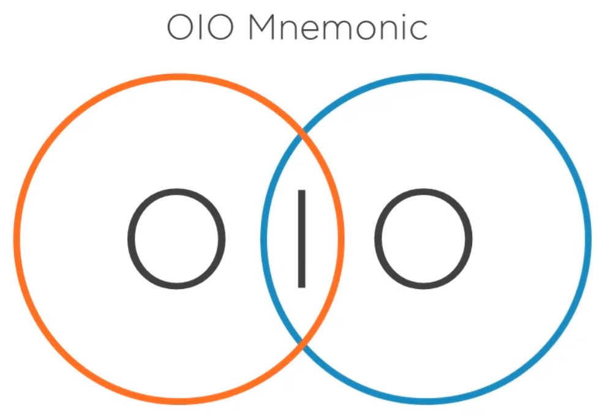

OIO Mnemonic Illustration Image

### Data Frame Keys

Key Columns: Primary Key and Foreign Keys.

- Primary Keys:
  - Is a column or combination of columns
  - Expresses a relationship about something it has in common with another data frame
  - Duplicates are not allowed
  - Missing values are not allowed
- Foreign Keys:
  - Is a column or combination of columns
  - Expresses a relationship about something it has in common with another data frame
  - Duplicates are allowed
  - Missing values are allowed

Ex:

```r
customers <- data.frame(customer_id = 1:3, name = c('Anna', 'Bill', 'Cliff'))

invoices <- data.frame(invoice_id = 1:5, total = c(100, 200, 300, 400, 500), cust_id = c(2, 3, 1, NA, 3))

customers
```

```
##   customer_id  name
## 1           1  Anna
## 2           2  Bill
## 3           3 Cliff
```

```r
invoices
```

```
##   invoice_id total cust_id
## 1          1   100       2
## 2          2   200       3
## 3          3   300       1
## 4          4   400      NA
## 5          5   500       3
```

Note that in the above data frames:

- customers data frame:
  - customer_id is the primary key (No duplicates or missing values)
- invoices data frame:
  - invoice_id is the primary key (No duplicates or missing values)
  - cust_id is the foreign key (has duplicates and NA values)(Expresses a relationship to customer_id col of customers data frame)

Lets perform an inner join of the two data frames with this knowledge:

```r
merge(invoices, customers, by.x = 'cust_id', by.y = 'customer_id')
```

```
##   cust_id invoice_id total  name
## 1       1          3   300  Anna
## 2       2          1   100  Bill
## 3       3          2   200 Cliff
## 4       3          5   500 Cliff
```

### Data Frame Relationships

Imagine you want to join to data frames and already have identified the primary and foreign keys on which to join

- Knowing the relationships between these keys makes it much easier to understand what to expect and get join results faster

Three most important relationships between two data frames:

- One-to-One
  - Each key in the left data frame has a corresponding key in the right

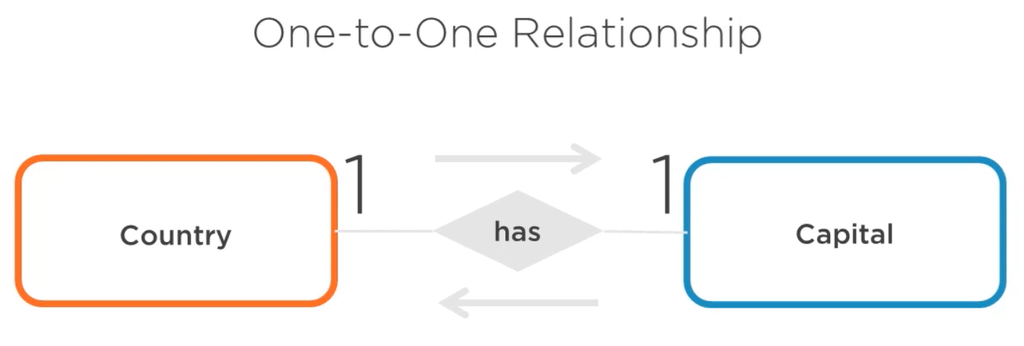

1to1 Relation Illustration Image

```r
# one-to-one relationship merge
countries <- data.frame(id = 1:3, name = c('USA', 'UK', 'Spain'))

capitals <- data.frame(city = c('London', 'Washington', 'Madrid'), country_id = c(2, 1, 3))

merge(countries, capitals, by.x = 'id', by.y = 'country_id')
```

```
##   id  name       city
## 1  1   USA Washington
## 2  2    UK     London
## 3  3 Spain     Madrid
```

- One-to-Many
  - Each key in the left data frame may have one or more corresponding keys in the right

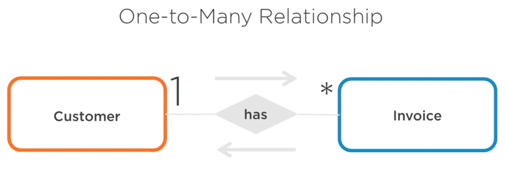

```r
# one-to-many relationship
customers <- data.frame(id=1:2, name=c('Anne', 'John'))

invoices <- data.frame(invoice_id=1:3, total=c(100, 200, 300), customer_id=c(1, 2, 2))

merge(customers, invoices, by.x = 'id', by.y = 'customer_id')
```

```
##   id name invoice_id total
## 1  1 Anne          1   100
## 2  2 John          2   200
## 3  2 John          3   300
```

- Many-to-Many
  - One or multiple keys in the left data frame may have one or more corresponding keys in the right

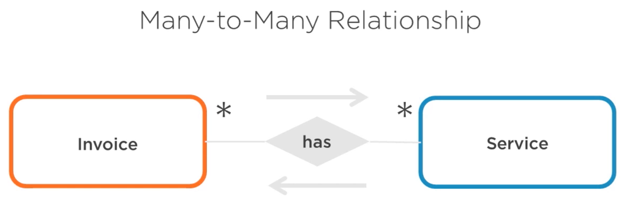

```r
# many-to-many relationship
invoices <- data.frame(invoice_id=1:2, total=c(1000, 2000))

services <- data.frame(service_id=1:2, name=c('consulting', 'training'))

# This third data frame stores the mappings between the first two allowing the many to many relationship to occur
invoicelines <- data.frame(service_id=c(1, 2, 1, 2), invoice_id=c(1, 1, 2, 2), price=c(500, 500, 1000, 1000))

merged_invoices_lines <- merge(invoices, invoicelines, by = 'invoice_id')
merged_invoices_lines
```

```
##   invoice_id total service_id price
## 1          1  1000          1   500
## 2          1  1000          2   500
## 3          2  2000          1  1000
## 4          2  2000          2  1000
```

```r
merged_services_invoices <- merge(merged_invoices_lines, services, by = 'service_id')
merged_services_invoices
```

```
##   service_id invoice_id total price       name
## 1          1          1  1000   500 consulting
## 2          1          2  2000  1000 consulting
## 3          2          1  1000   500   training
## 4          2          2  2000  1000   training
```